# Permutation Tests

December 6, 2024

Mayra Coruh

## LAhomes Dataset

```r
library(tidyverse)
library(ggplot2)
library(openintro)
library(dplyr)
data(LAhomes)
```

```r
head(LAhomes)
```

```
# A tibble: 6 × 8
  city       type    bed  bath garage  sqft pool   price
  <chr>      <chr> <dbl> <dbl>  <dbl> <dbl> <chr>  <dbl>
1 Long Beach <NA>      0     1      0   513 N     119000
2 Long Beach <NA>      0     1      0   550 N     153000
3 Long Beach <NA>      0     1      0   550 N     205000
4 Long Beach <NA>      0     1      1  1030 N     300000
5 Long Beach <NA>      0     1      1  1526 N     375000
6 Long Beach <NA>      1     1      0   552 N     159900
```

I conduct a permutation test to assess whether the city in which a home is located (specifically between Santa Monica and Long Beach) is associated with the listing price.

Research Question: How are the listing prices of homes in Santa Monica and Long Beach, within the population of homes listed for sale in Los Angeles in 2010, associated with their locations?

Null Hypothesis: For the population of homes listed for sale in Los Angeles in 2010, there is no difference in the mean listing prices of homes between Santa Monica and Long Beach.

## How Do I Perform the Permutation Test?

- Filtering the data to only include homes from these two cities.
- Creating a function that calculates the permuted mean difference in listing prices by randomly shuffling the city labels while keeping the prices fixed.
- This process is repeated multiple times through the map() function to generate a distribution of permuted mean differences under the null hypothesis, which states that the mean listing prices between the two cities are the same.
- Calculating the observed mean difference and comparing it to the distribution of permuted differences to compute the p-value.
- Visualizing the distribution of these permuted mean differences and marking the observed mean difference to assess its significance.

## The Code for the Permutation Test

```r
twoLAhomes <- LAhomes |>
  filter(city %in% c("Santa Monica", "Long Beach"))

perm_data <- function(rep, data) {
  data |>
    mutate(city_perm = sample(city, replace = FALSE)) |>
    group_by(city_perm) |>
    summarise(
      perm_ave = mean(price, na.rm = TRUE)
    ) |>
    summarise(
      perm_ave_diff = diff(perm_ave),
      rep = rep
    )
}

observed_diff <- twoLAhomes |>
  group_by(city) |>
  summarise(obs_ave = mean(price, na.rm = TRUE)) |>
  mutate(obs_ave_diff = diff(obs_ave)) |>
  pull(obs_ave_diff)

set.seed(123)
num_reps <- 500
perm_results <- map_dfr(1:num_reps, ~ perm_data(.x, twoLAhomes))

p_value <- mean(abs(perm_results |> pull(perm_ave_diff)) > observed_diff)

p_value
```

```
[1] 0
```

Walking Through the Code;

- First, I created a function that calculates the permuted mean difference. This function shuffles the city labels while keeping the prices fixed, simulating what the mean difference would look like under the null hypothesis.
- Using the map_dfr() function, I ran 500 iterations of this permutation process and compiled the results into a data frame.
- Then, I visualized the results by plotting a histogram of the distribution of permuted mean differences and marked the observed mean difference with a red dashed line for comparison.
- Finally, I calculated the p-value to determine the proportion of permuted mean differences that were greater than the observed mean difference.
- Under the null hypothesis and assuming that the average home prices in Santa Monica and Long Beach come from the same distribution, the p-value represents the probability of observing a mean difference as large as the actual observed difference (754,943.92) by random chance. If the p-value is approximately 0%, this indicates that it is highly unlikely to observe such a difference under the null hypothesis. Therefore, we can reject the null hypothesis and conclude that there is a significant difference in the average home prices between Santa Monica and Long Beach.

## Visualisation

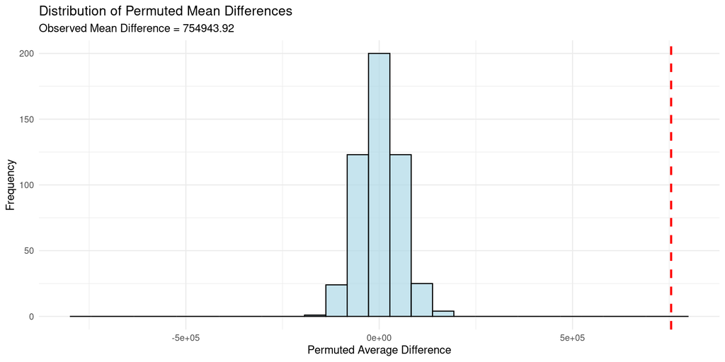

## Insights from the Plot:

- Histogram depicts the distribution of permuted mean differences under the null hypothesis, which assumes there is no significant difference in mean home prices between Santa Monica and Long Beach. The fact that the distribution is centered around zero indicates that when city labels are shuffled, the mean difference is typically around zero.
- Red dashed line represents the observed mean difference (754,943.92) between the actual home prices in Santa Monica and Long Beach. This value is beyond the range of most of the permuted mean differences.
- The observed mean difference is far to the right of the distribution of permuted differences, suggesting that the observed difference is unlikely to occur by random chance. Hence, the city (Santa Monica or Long Beach) has a significant effect on the mean home price.
- Since the calculated p-value is approximately 0, it can be said that the observed mean difference is statistically significant. By suggesting that the mean home price in Santa Monica and Long beach differ significantly, the p-value allows us to reject the null hypothesis.